# FAIR, agil und reproduzierbar – moderner Umgang mit Daten und Analysen im Gesundheitswesen

Author

Daniel Stekhoven

Published

March 16, 2025

## 1 Einführung

Dieser Kursabschnitt befasst sich mit modernen Konzepten des Datenmanagements und der Analyse im Gesundheitswesen. Der Fokus liegt auf der Bedeutung der FAIR-Prinzipien (Wilkinson et al. 2016), agiler Softwareentwicklung (Beck et al. 2001) und der Reproduzierbarkeit wissenschaftlicher Analysen (Munafò et al. 2017). Das Skript ist eine Ergänzung zur Vorlesung *FAIR, agil und reproduzierbar – moderner Umgang mit Daten und Analysen im Gesundheitswesen*, welche Teil der Vorlesungsreihe *Digitale Biomarker* im Bachelor Humanmedizin der ETH Zürich ist.

## 2 Herausforderungen im Gesundheitsdaten-Management

Gesundheitsdaten sind komplex, sensibel und oft schwierig zu verwalten. Sie werden deswegen nur selten für Forschung und Entwicklung wiederverwendet (Gaudet-Blavignac et al. 2021). Zentrale Herausforderungen umfassen Datenschutz, Interoperabilität zwischen Systemen, Qualitätssicherung und die ständig wachsende Menge an Daten (Big Data) (Abouelmehdi, Beni-Hessane, and Khaloufi 2018).

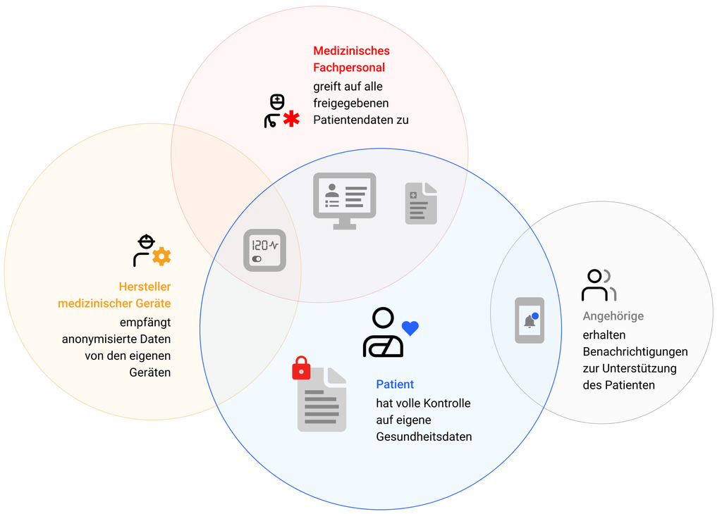

Zugriff auf Gesundheitsdaten aus verschiedenen Perspektiven. Abbildung: Helbling[^1]

## 3 FAIR-Prinzipien

FAIR steht für Findable (auffindbar), Accessible (zugänglich), Interoperable (kompatibel) und Reusable (wiederverwendbar) (Wilkinson et al. 2016). Diese Prinzipien unterstützen ein effizientes Datenmanagement und fördern den Austausch zwischen Forschenden, insbesondere unabhängig von den verwendeten Infrastrukturen (Mons et al. 2017).

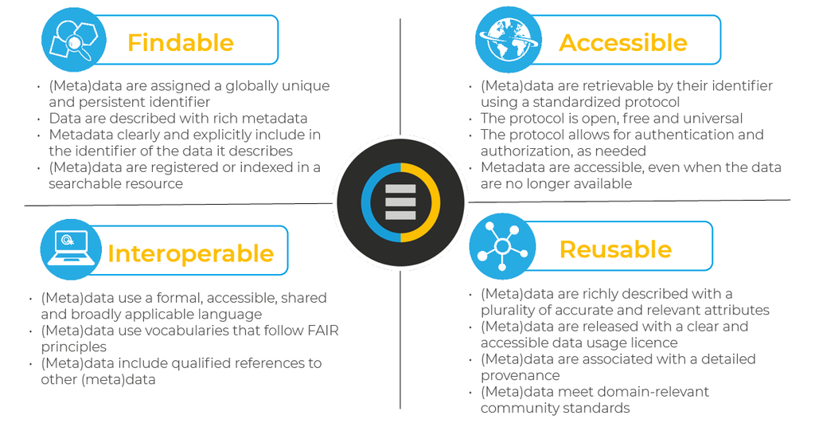

Die FAIR Data Principles legen Kriterien fest, die es ermöglichen, die Philosophie der Offenheit durch moderne Veröffentlichungspraktiken und Infrastrukturen, die die aktuellen Anforderungen der Datenwissenschaft unterstützen, konkret umzusetzen. Abbildung: Cambridge Cristallographic Data Centre (CCDC)[^2]

## 4 FAIR in der Praxis

Die FAIR-Prinzipien ermöglichen, dass Daten einfacher von verschiedenen Akteuren genutzt werden können (Wilkinson et al. 2016). Erfolgreiche Implementierungen der FAIR-Prinzipien führen nachweislich zu erhöhter Forschungsqualität und beschleunigten Entdeckungen (Sansone et al. 2019; Boeckhout, Zielhuis, and Bredenoord 2018). Manchmal sind Daten aber nicht einfach teilbar, dann ist es hilfreich, wenn man die Metadaten teilen kann (Silva Santos et al. 2023).

#### *Praxisbeispiel: LUMC und SURF in Holland*

Im Medizinischen Zentrum der Universität Leiden (LUMC) wird der FAIR Data Point (FDP, Silva Santos et al. 2023) eingesetzt, um Metadaten über COVID-Patientendaten im Interesse der Forschung so offen wie möglich zu machen, während die Daten notwendigerweise nicht verfügbar sind und in einer Vielzahl verschiedener Systeme gespeichert werden. Im Gegensatz dazu wendet der niederländische Datendienstleister SURF die FDP an, um die FAIRness eines umfangreichen Datensatzspeichers zu verbessern, der standardmäßig offen zugänglich ist (Whyte, O’Connor, and Nordling 2022).

## 5 Agile Softwareentwicklung

Agile Softwareentwicklung beschreibt iterative und flexible Entwicklungsmethoden, welche schnelle Anpassungen und kontinuierliches Feedback ermöglichen. Die Entwicklung erfolgt in kurzen Zyklen (Sprints) und integriert Nutzerfeedback frühzeitig (Beck et al. 2001; Abrahamsson et al. 2002).

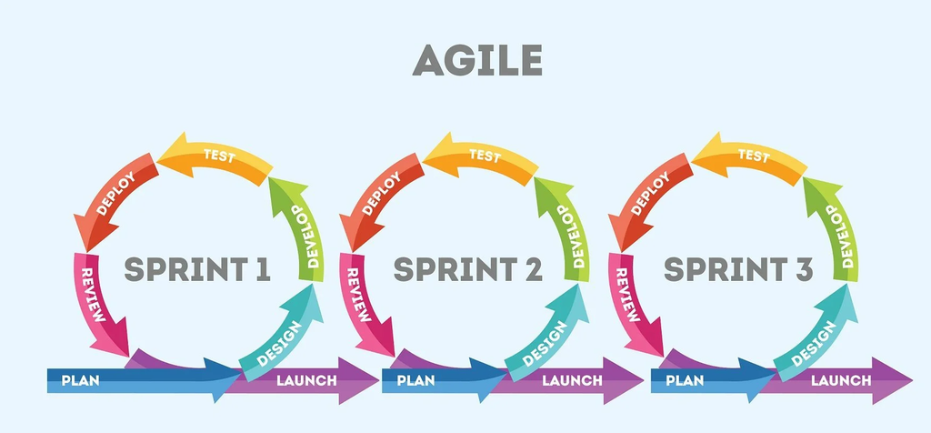

Agile Softwareentwicklung zeichnet sich durch das schrittweise Erarbeiten einer Lösung in mehreren Sprints aus. Abbildung: SolDevolo[^3]

## 6 Besonderheiten der Softwareentwicklung im Gesundheitswesen

Im Gesundheitswesen stellen regulatorische Vorgaben, Datenschutzbestimmungen und hohe Anforderungen an Datensicherheit besondere Herausforderungen für die Softwareentwicklung dar (McGraw and Mandl 2021). Diese müssen bereits in frühen Entwicklungsphasen berücksichtigt werden und auf pragmatische, auf die Endnutzer ausgerichtete Produkte hervorbringen (Mathews et al. 2019).

Es gibt aber auch noch andere Punkte, die einen grossen Einfluss haben:

1. Unzureichende Strategie und Ausführungsplan
2. Fehlende Akzeptanz bei den Beteiligten
3. Die Last veralteter Prozesse
4. Veraltete Systeme und Schwierigkeiten bei der Integration mit neuen Technologien
5. Fehlende Priorisierung von Schulung und Einführung

Diese Punkte werden als einige der grössten Herausforderungen bei der digitalen Transformation verstanden[^4]. Sie gelten eins zu eins für die Entwicklung von Software im Gesundheitswesen.

## 7 Reproduzierbarkeit in Analysen

Reproduzierbarkeit bedeutet, dass wissenschaftliche Ergebnisse und Analysen durch unabhängige Forschende nachvollzogen und verifiziert werden können. Fehlende Reproduzierbarkeit führt oft zu Unsicherheiten, Verzögerungen und Verschwendung von Ressourcen (Ioannidis 2005). Seit vielen Jahren befindet sich die Forschung in eine regelrechten Reproduzierbarkeitskrise (Baker 2016; Nosek et al. 2022; Errington et al. 2021). Die Gemeinschaft reagiert zaghaft darauf und Initiativen zur Förderung von rigoroser, transparenter und reproduzierbarer Forschung sind entstanden (for instance “From Grassroots to Global: A Blueprint for Building a Reproducibility Network” 2021).

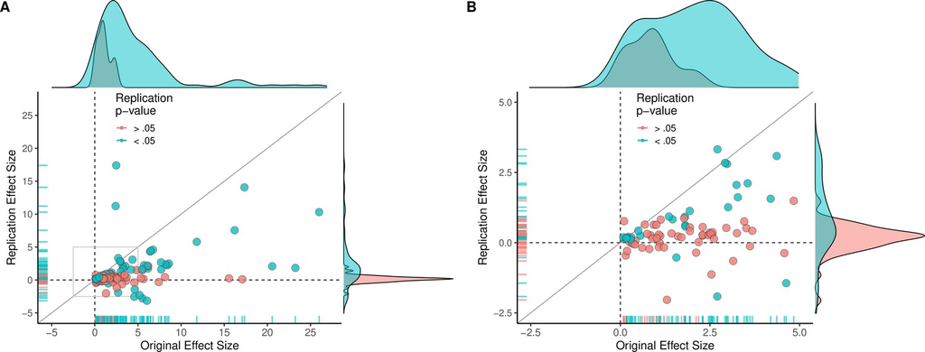

(A) Diagramm, in dem jeder Kreis einen Effekt darstellt, für den eine SMD-Effektgrösse sowohl für den ursprünglichen Effekt als auch für die Replikation berechnet werden konnte (n=110). Blaue Kreise zeigen Effekte an, für die p<0.05 in der Replikation war, und rote Kreise zeigen p>0.05 an. Zwei Effekte, für die die ursprüngliche Effektgröße >80 war, sind nicht dargestellt. Der Median der Effektgrösse in den Replikationen war 85% kleiner als der Median der Effektgrösse in den ursprünglichen Experimenten, und 97% der Effektgrössen in den Replikationen waren kleiner als die ursprünglichen Effektgrössen (unterhalb der grauen diagonalen Linie). (B) Eine erweiterte Ansicht von Feld A für Effektgrössen < 5 (grauer Umriss in Feld A). SMD: Standard Mean Differenz. (Abbildung: Errington et al. 2021)

## 8 Vorteile der Reproduzierbarkeit

Reproduzierbare Forschung erhöht die Vertrauenswürdigkeit, Qualität und Effizienz wissenschaftlicher Arbeit, da Ergebnisse und Analysen unabhängig überprüft werden können (Munafò et al. 2017; Peng 2011; Cobey et al. 2024). Im Gesundheitswesen verbessert Reproduzierbarkeit die klinische Entscheidungsfindung und stärkt die Grundlage für evidenzbasierte Medizin (Niven et al. 2018). Interoperabilität, als wesentliche Komponente der Reproduzierbarkeit, ermöglicht zudem den Austausch und die Nutzung von Daten und Ergebnissen über verschiedene Systeme und Organisationen hinweg, was die Zusammenarbeit zwischen Forschungseinrichtungen, Kliniken und Industriepartnern vereinfacht und dadurch Innovation und medizinische Fortschritte beschleunigt (Gaudet-Blavignac et al. 2021). Insgesamt fördert reproduzierbare Forschung Transparenz, minimiert Fehlerpotenziale und reduziert unnötige Kosten und Ressourcenverschwendung (Freedman, Cockburn, and Simcoe 2015).

## References

Abouelmehdi, Karim, Abderrahim Beni-Hessane, and Hayat Khaloufi. 2018. “Big Healthcare Data: Preserving Security and Privacy.” *Journal of Big Data* 5 (1). https://doi.org/10.1186/s40537-017-0110-7.

Abrahamsson, Pekka, Outi Salo, Jussi Ronkainen, and Juhani Warsta. 2002. *Agile Software Development Methods: Review and Analysis*. VTT Publications 478. Finland: VTT Technical Research Centre of Finland.

Baker, Monya. 2016. “1,500 Scientists Lift the Lid on Reproducibility.” *Nature* 533 (7604): 452–54. https://doi.org/10.1038/533452a.

Beck, Kent, Mike Beedle, Arie van Bennekum, Alistair Cockburn, Ward Cunningham, Martin Fowler, James Grenning, et al. 2001. “Manifesto for Agile Software Development.” http://www.agilemanifesto.org/.

Boeckhout, Martin, Gerhard A. Zielhuis, and Annelien L. Bredenoord. 2018. “The FAIR Guiding Principles for Data Stewardship: Fair Enough?” *European Journal of Human Genetics* 26 (7): 931–36. https://doi.org/10.1038/s41431-018-0160-0.

Cobey, Kelly D., Sanam Ebrahimzadeh, Matthew J. Page, Robert T. Thibault, Phi-Yen Nguyen, Farah Abu-Dalfa, and David Moher. 2024. “Biomedical Researchers’ Perspectives on the Reproducibility of Research.” Edited by Cilene Lino de Oliveira. *PLOS Biology* 22 (11): e3002870. https://doi.org/10.1371/journal.pbio.3002870.

Errington, Timothy M, Maya Mathur, Courtney K Soderberg, Alexandria Denis, Nicole Perfito, Elizabeth Iorns, and Brian A Nosek. 2021. “Investigating the Replicability of Preclinical Cancer Biology.” *eLife* 10 (December). https://doi.org/10.7554/elife.71601.

Freedman, Leonard P., Iain M. Cockburn, and Timothy S. Simcoe. 2015. “The Economics of Reproducibility in Preclinical Research.” *PLOS Biology* 13 (6): e1002165. https://doi.org/10.1371/journal.pbio.1002165.

“From Grassroots to Global: A Blueprint for Building a Reproducibility Network.” 2021. *PLOS Biology* 19 (11): e3001461. https://doi.org/10.1371/journal.pbio.3001461.

Gaudet-Blavignac, Christophe, Jean Louis Raisaro, Vasundra Touré, Sabine Österle, Katrin Crameri, and Christian Lovis. 2021. “A National, Semantic-Driven, Three-Pillar Strategy to Enable Health Data Secondary Usage Interoperability for Research Within the Swiss Personalized Health Network: Methodological Study.” *JMIR Medical Informatics* 9 (6): e27591. https://doi.org/10.2196/27591.

Ioannidis, John P. A. 2005. “Why Most Published Research Findings Are False.” *PLoS Medicine* 2 (8): e124. https://doi.org/10.1371/journal.pmed.0020124.

Mathews, Simon C., Michael J. McShea, Casey L. Hanley, Alan Ravitz, Alain B. Labrique, and Adam B. Cohen. 2019. “Digital Health: A Path to Validation.” *Npj Digital Medicine* 2 (1). https://doi.org/10.1038/s41746-019-0111-3.

McGraw, Deven, and Kenneth D. Mandl. 2021. “Privacy Protections to Encourage Use of Health-Relevant Digital Data in a Learning Health System.” *Npj Digital Medicine* 4 (1). https://doi.org/10.1038/s41746-020-00362-8.

Mons, Barend, Cameron Neylon, Jan Velterop, Michel Dumontier, Luiz Olavo Bonino da Silva Santos, and Mark D. Wilkinson. 2017. “Cloudy, Increasingly FAIR; Revisiting the FAIR Data Guiding Principles for the European Open Science Cloud.” *Information Services and Use* 37 (1): 49–56. https://doi.org/10.3233/isu-170824.

Munafò, Marcus R., Brian A. Nosek, Dorothy V. M. Bishop, Katherine S. Button, Christopher D. Chambers, Nathalie Percie du Sert, Uri Simonsohn, Eric-Jan Wagenmakers, Jennifer J. Ware, and John P. A. Ioannidis. 2017. “A Manifesto for Reproducible Science.” *Nature Human Behaviour* 1 (1). https://doi.org/10.1038/s41562-016-0021.

Niven, Daniel J., T. Jared McCormick, Sharon E. Straus, Brenda R. Hemmelgarn, Lianne Jeffs, Tavish R. M. Barnes, and Henry T. Stelfox. 2018. “Reproducibility of Clinical Research in Critical Care: A Scoping Review.” *BMC Medicine* 16 (1). https://doi.org/10.1186/s12916-018-1018-6.

Nosek, Brian A., Tom E. Hardwicke, Hannah Moshontz, Aurélien Allard, Katherine S. Corker, Anna Dreber, Fiona Fidler, et al. 2022. “Replicability, Robustness, and Reproducibility in Psychological Science.” *Annual Review of Psychology* 73 (1): 719–48. https://doi.org/10.1146/annurev-psych-020821-114157.

Peng, Roger D. 2011. “Reproducible Research in Computational Science.” *Science* 334 (6060): 1226–27. https://doi.org/10.1126/science.1213847.

Sansone, Susanna-Assunta, Peter McQuilton, Philippe Rocca-Serra, Alejandra Gonzalez-Beltran, Massimiliano Izzo, Allyson L. Lister, and Milo Thurston. 2019. “FAIRsharing as a Community Approach to Standards, Repositories and Policies.” *Nature Biotechnology* 37 (4): 358–67. https://doi.org/10.1038/s41587-019-0080-8.

Silva Santos, Luiz Olavo Bonino da, Kees Burger, Rajaram Kaliyaperumal, and Mark D. Wilkinson. 2023. “FAIR Data Point: A FAIR-Oriented Approach for Metadata Publication.” *Data Intelligence* 5 (1): 163–83. https://doi.org/10.1162/dint_a_00160.

Whyte, Angus, Ryan O’Connor, and Josefine Nordling. 2022. “Making the Case for FAIR Data Points,” April. https://doi.org/10.5281/ZENODO.6256839.

Wilkinson, Mark D., Michel Dumontier, IJsbrand Jan Aalbersberg, Gabrielle Appleton, Myles Axton, Arie Baak, Niklas Blomberg, et al. 2016. “The FAIR Guiding Principles for Scientific Data Management and Stewardship.” *Scientific Data* 3 (1). https://doi.org/10.1038/sdata.2016.18.

## Footnotes

[^1]: Die Herausforderung der Datenintegration im Gesundheitswesen aus drei Perspektiven, [Insight, September 2023](https://helbling.ch/de/insights/die-herausforderung-der-datenintegration-im-gesundheitswesen-aus-drei-perspektiven-1)
[^2]: FAIR Data Principles, https://www.ccdc.cam.ac.uk/solutions/about-the-csd/fair-data-principles/
[^3]: Is Agile always the best solution for software development projects? https://soldevelo.com/blog/is-agile-always-the-best-solution-for-software-development-projects/
[^4]: Die 5 größten Herausforderungen bei der digitalen Transformation, DECODE, 15. Juni 2023, https://www.zoho.com/de/creator/decode/top-5-digital-transformation-herausforderungen